```python
from IPython.display import Image
```

# Classification Prediction Quality - Theory

## Classification Prediction Quality - Introduction

Suppose we are predicting two outcomes: 1 or 0, where 1 is a positive outcome and 0 is a negative outcome. A model's prediction on test data falls under four categories:

- True positive. Model predicts 1 and the actual data is 1
- False positive. Model predicts 1 but the actual data is 0
- True negative. Model predicts 0 and the actual data is 0
- False negative. Model predicts 0 and the actual data is 1

This is important to break down because decisions based off of positive and negative predictions have costs. Consider the example of diagnosing a patient with cancer:

- False positive. If the patient does not have cancer but is diagnosed with cancer, then this will be a lot of cost and stress for no reason.
- False negative. If the patient does have cancer but is diagnosed as not having cancer, then they will go untreated.

For a doctor, the implications of a false negative is worse than a false positive for two reasons:

- A human life is at stake!
- For the more cynical, a false positive will bring in more money for the doctor

There is actually a debate over to what extent doctors are incentivized to over-diagnose.

## Confusion Matrices

This is a matrix which demonstrates how many predicted outcomes fall into each prediction category:

- True Positive (TP)
- False Postiive (FP)
- True Negative (TN)
- False Negative (FN)

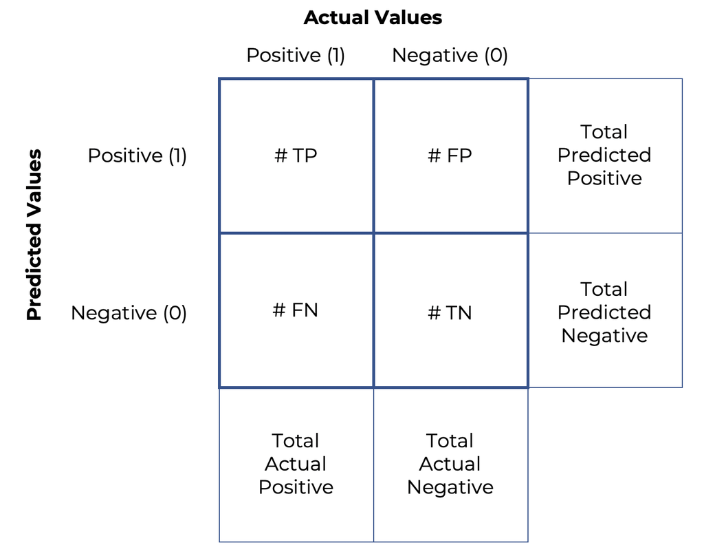

```python
Image("img/confusion_matrix.png")
```

Using the results of the confusion matrix, we can calculate different metrics to evaluate the model:

- True postive rate (also known as **sensitivity** or **recall**)
- True negative rate (also known as **specificity**)
- False positive rate (also known as **fall out**)
- False negative rate
- Precision
- F-score
- Accuracy
- Misclassification rate

### True Positive Rate

$tpr = \frac{tp}{(tp+fn)} = \frac{tp}{(Total\:Actual\:Positive)}$

This is a measure of how good the model is at predicting the positive condition.

### True Negative Rate

$fnr = \frac{tn}{(tn+fp)} = \frac{tp}{(Total\:Actual\:Negative)}$

This is a measure of how good the model is at predicting the negative condition.

### False Positive Rate

$fpr=\frac{fp}{(fp+tn)}=\frac{tp}{(Total\:Actual\:Negative)}$

This is a measure of the proportion of negative outcomes that have been predicted as positive.

### False Negative Rate

$fpr=\frac{fn}{(tp+fn)}=\frac{tp}{(Total\:Actual\:Positive)}$

This is a measure of the proportion of positive outcomes that have been predicted as negative.

### Precision

$precision=\frac{tp}{(tp+fp)}=\frac{tp}{(Total\:Predicted\:Positive)}$

This measures the proportion of cases predicted as positive that are actually positive.

### f-score

$fscore=2\frac{precision\cdot recall}{(precision+recall)}$

This combines precision and recall into one metric. Why would we want to do this?

- Precision is a measure of how well the model is at predicting positive outcomes (i.e. a precision of 1 means that every positive prediction is a true positive)
- Recall is a measure of how good the model is at finding positive outcomes (i.e. a recall of 1 means that every positive outcome is found)
- Recall can equal 1 if we just label everything as positive -- does not discriminate well
- Precision can equal 1 even if we ignore all the false negatives (which are actual positives) -- does not find all positives well
- Combining into one score allows us to evaluate both simultaneously

### Accuracy

$accuracy = \frac{tp+tn}{(tp+tn+fp+fn)}=\frac{tp+tn}{(Total\:Outcomes)}$

This is a measure of how accurately we classify true positives and negatives.

### Misclassification Rate

$misclassification = \frac{fp+fn}{(tp+tn+fp+fn)}=\frac{fp+fn}{(Total\:Outcomes)} = 1-accuracy$

This is a measure of how often we misclassify positives and negatives and is the inverse of accuracy.

## Receiver Order Characteristic (ROC) Curve

Recall that in the **Basic Classification** module, we can fine-tune how classifications are made by applying different thresholds $\tau$ for when a positive or negative prediction is made.

- E.x. For a logistic regression model, we can set a threshold $\tau=0.5$ which means that if the predicted outcome has a probability greater than 0.5 of being positive, label it as positive, else negative

As $\tau$ increases, precision goes up but recall goes down because the false positive rate decreases. It is important we understand how the false and positive rates change as $\tau$ changes.

Enter the Receiver Order Characteristic (ROC) Curve!

- This plots the false positive rate (fall out) on the x-axis and true positive rate (recall) on the y-axis to show how the two relate

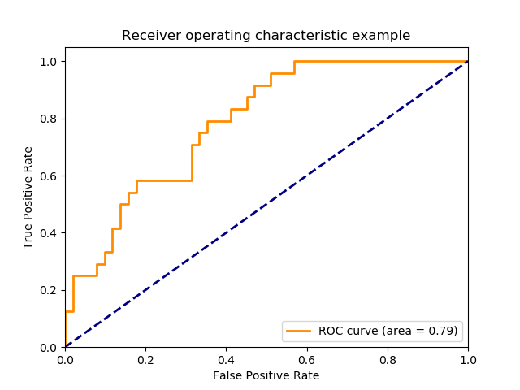

```python
Image('img/roc_curve.png')
```

Source: sklearn documentation

The orange line is constructed by plotting the results of different values of $\tau$.

- If the model with threshold $\tau$ captures no positive outcomes, then we never predict a positive outcome and both the true and false positive rates are 0
- If the model with threshold $\tau$ captures all positive outcomes, then we always predict a all true and false positive rates
- This is why the curve looks the way it does from left to right

The blue dotted line in the middle represents what would happen if we just guessed randomly, and is always a linear line with slope 1. If the ROC curve is below this line, then the model is worse than guessing randomly.

### Area Under Curve (AUC)

The area below the curve (everything under the orange line) is a measure of how stable the model is to changes in threshold. We want to maximize this area.

## Precision-Recall Curve

Recall the following that we said about precision and recall:

- Precision is a measure of how well the model is at predicting positive outcomes (i.e. a precision of 1 means that every positive prediction is a true positive)
- Recall is a measure of how good the model is at finding positive outcomes (i.e. a recall of 1 means that every positive outcome is found)
- Recall can equal 1 if we just label everything as positive -- does not discriminate well
- Precision can equal 1 even if we ignore all the false negatives (which are actual positives) -- does not find all positives well

Additionally, recall that as $\tau$ increases, precision goes up and recall goes down.

In an ideal situation, we would like both numbers to be close to 1! We can plot the precision and recall as $\tau$ changes to understand how both metrics change as $\tau$ changes.

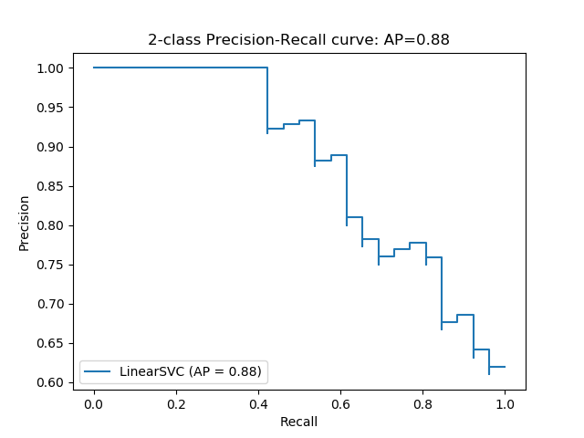

```python
Image('img/precision_recall_graph.png')
```

We can also compute an **average precision (AP)** metric from the precision-recall curve.

- AP computes a score at each threshold point defined as:
  - Precision at that point multiplied by the change in recall from the previous threshold point
- Sum all results to give a weighted average

## ROC vs Precision-Recall

Both ROC and Precision-Recall curves give a sense of the quality of a classifier and how sensitive it is to changes in threshold.

- ROC curves should be used when a class is balanced (there are roughly equal numbers of each kind of observation)
  - E.x. 50% of outcomes are 1 and 50% of outcomes are 0
- Precision-Recall curves should be used when there is a moderate to large class imbalance
  - E.x. 20% of outcomes are 1 and 80% of outcomes are 0

## Selecting $\tau$ Threshold

It depends on the factors in the domain or the business case. This is because there are different costs associated with true positive, true negative, false positive, and false negative outcomes. These varying costs can be viewed as economic tradeoffs in informing an optimal threshold.

An easy way of understanding these costs is to create a cost matrix of how much each outcome costs.

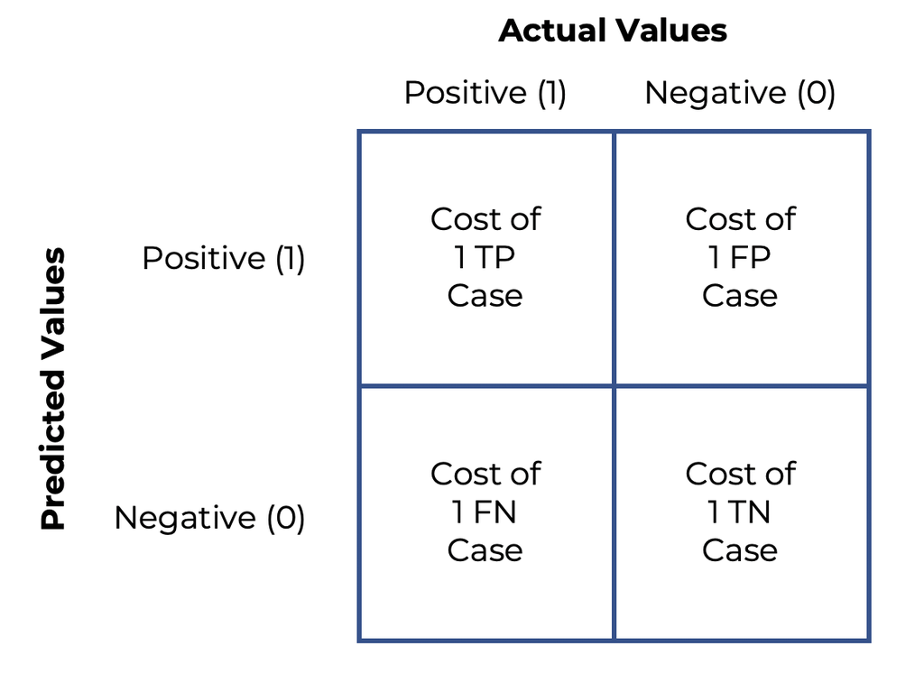

```python
Image("img/cost_matrix.png")
```

We can multiply together the cost and confusion matrices to get the cost of a model:

- $Cost = (TP_{total} \cdot TP_{cost})+(FP_{total} \cdot FP_{cost})+(FN_{total} \cdot FN_{cost})+(TN_{total} \cdot TN_{cost})$

As we know, the number of TP, FP, FN, and TN cases are all impacted by $\tau$, so we can select $\tau$ based off which $\tau$ gives the best cost output. In this example, we are minimizing cost -- so whichever $\tau$ creates a model with the lowest cost.

- However you could also flip this and make it about maximizing revenue

Example:

- Suppose a true positive costs company X \$200
- Suppose a false positive costs company X \$300
- Suppose a true negative costs company X \$100
- Suppose a false negative costs company X \$400

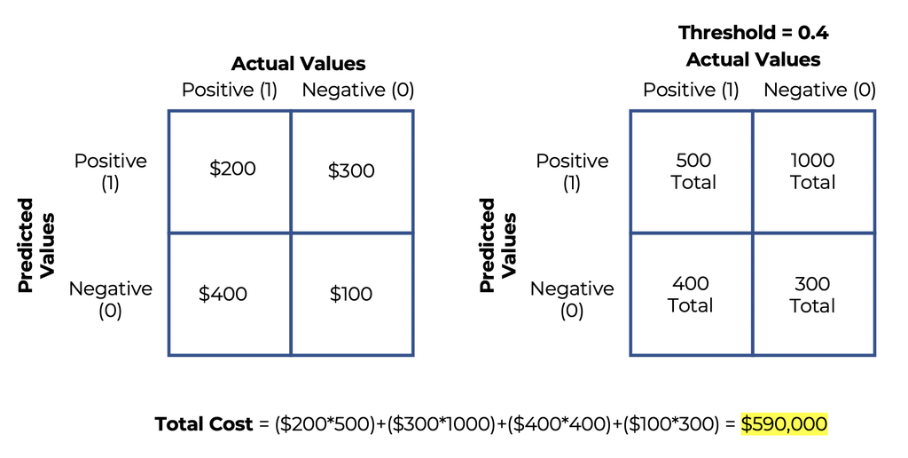

```python
Image("img/threshold_1.png")
```

[figure not shown]

```python
Image("img/threshold_2.png")
```

## More Resources

[One ROC Curve and Cutoff Analysis](https://ncss-wpengine.netdna-ssl.com/wp-content/themes/ncss/pdf/Procedures/NCSS/One_ROC_Curve_and_Cutoff_Analysis.pdf)